# Introduction to data science - Ch3-Ch4

# Welcome to melda.io

You can start working by adding new cells.

Use the button “Add new cell” located right below this cell. # VERİ TEMİZLEMESİ VE KALİTE KONTROLÜ (Managing data) This chapter covers

- Fixing data quality problems
- Organizing your data for the modeling process

```r
library(ggplot2)
```

**Cleaning data**

Treating missing values (NAs)

```r
custdata <- read.table('https://github.com/scizmeli/datascience_class_helper_files/raw/master/custdata1.tsv',header=T,sep=',')
```

```r
summary(custdata[is.na(custdata$housing.type),c("recent.move","num.vehicles")])
```

```
##  recent.move     num.vehicles
##  Mode:logical   Min.   : NA
##  NA's:56        1st Qu.: NA
##                 Median : NA
##                 Mean   :NaN
##                 3rd Qu.: NA
##                 Max.   : NA
##                 NA's   :56
```

**TO DROP OR NOT TO DROP?**

There are two things you can do with these variables:

drop the rows with missing values or convert the missing values to a meaningful value. **MISSING VALUES IN CATEGORICAL DATA**

```r
summary(custdata[,c("housing.type" ,"recent.move" , "num.vehicles" , "is.employed")])
```

```
##                        housing.type recent.move      num.vehicles
##  Homeowner free and clear    :157   Mode :logical   Min.   :0.000
##  Homeowner with mortgage/loan:412   FALSE:820       1st Qu.:1.000
##  Occupied with no rent       : 11   TRUE :124       Median :2.000
##  Rented                      :364   NA's :56        Mean   :1.916
##  NA's                        : 56                   3rd Qu.:2.000
##                                                     Max.   :6.000
##                                                     NA's   :56
##  is.employed
##  Mode :logical
##  FALSE:73
##  TRUE :599
##  NA's :328
##
##
##
```

The is.employed variable is missing many values.

**Why?**

Is employment status unknown?

```r
custdata$is.employed.fix <- ifelse(is.na(custdata$is.employed),
"missing",
ifelse(custdata$is.employed==T,
"employed",
"not employed"))
summary(as.factor(custdata$is.employed.fix))
```

```
##     employed      missing not employed
##          599          328           73
```

```r
custdata$is.employed.fix <- ifelse(is.na(custdata$is.employed),
"not in active workforce",
ifelse(custdata$is.employed==T,
"employed",
"not employed"))
summary(as.factor(custdata$is.employed.fix))
```

```
##                employed            not employed not in active workforce
##                     599                      73                     328
```

**Why a new variable?** **MISSING VALUES IN NUMERIC DATA**

```r
summary(custdata$Income)
```

```
##    Min. 1st Qu.  Median    Mean 3rd Qu.    Max.    NA's
##       0   25000   45000   66199   82000  615000     328
```

```r
meanIncome <- mean(custdata$Income, na.rm=T)
meanIncome
```

```
## [1] 66198.67
```

You believe that income is still an important so you still want to use the variable. What do you do? WHEN VALUES ARE MISSING **RANDOMLY**

You might believe that the data is missing because of a faulty sensor—in other words, the data collection failed at random. In this case, you can replace the missing values with the expected, or mean, income

```r
meanIncome <- mean(custdata$Income, na.rm=T)
```

```r
Income.fix <- ifelse(is.na(custdata$Income),
meanIncome, custdata$Income)
```

```r
summary(Income.fix)
```

```
##    Min. 1st Qu.  Median    Mean 3rd Qu.    Max.
##       0   35000   66199   66199   66199  615000
```

WHEN VALUES ARE MISSING **SYSTEMATICALLY**

One thing you can do is to convert the numeric data into categorical data, and then use the methods that we discussed previously. In this case, you would divide the income into some income categories of interest, such as “below $10,000,” or “from $100,000 to $250,000” using the cut() function, and then treat the NAs as we did when working with missing categorical values

```r
breaks <-c(0, 10000, 50000, 100000, 250000, 1000000)
```

```r
Income.groups <-
cut(custdata$Income,breaks = breaks, include.lowest=T)
```

```r
summary(Income.groups)
```

```
##       [0,1e+04]   (1e+04,5e+04]   (5e+04,1e+05] (1e+05,2.5e+05] (2.5e+05,1e+06]
##              63             312             178              98              21
##            NA's
##             328
```

```r
Income.groups <- as.character(Income.groups)
```

```r
Income.groups <- ifelse(is.na(Income.groups),"no income", Income.groups)

summary(as.factor(Income.groups))
```

```
##   (1e+04,5e+04] (1e+05,2.5e+05] (2.5e+05,1e+06]   (5e+04,1e+05]       [0,1e+04]
##             312              98              21             178              63
##       no income
##             328
```

**Tracking original NAs with an extra categorical variable**

The missingIncome variable lets you differentiate the two kinds of zeros in the data:

the ones that you are about to add,

and the ones that were already there.

```r
missingIncome <- is.na(custdata$Income)
Income.fix <- ifelse(is.na(custdata$Income), 0, custdata$Income)
```

In summary, to properly handle missing data you need to know why the data is missing in the first place.

If you don’t know whether the missing values are random or systematic, we recommend assuming that the difference is systematic # Data transformations

The purpose of data transformation is to make data easier to model—and easier to understand. In this section, we’ll look at some useful data transformations and when to use them: converting continuous variables to discrete; normalizing variables; and log transformations. Normalizing income by state

```r
medianincome <- aggregate(income~state.of.res,custdata,FUN=median)
colnames(medianincome) <- c('State','Median.Income')
summary(medianincome)
```

```
##         State    Median.Income
##  Alabama   : 1   Min.   :  6300
##  Alaska    : 1   1st Qu.: 28400
##  Arizona   : 1   Median : 36050
##  Arkansas  : 1   Mean   : 39776
##  California: 1   3rd Qu.: 42938
##  Colorado  : 1   Max.   :139000
##  (Other)   :44
```

```r
is.data.frame(medianincome)
```

```
## [1] TRUE
```

```r
head(medianincome)
```

|  | State | Median.Income |
| --- | --- | --- |
| 1 | Alabama | 39900 |
| 2 | Alaska | 41000 |
| 3 | Arizona | 52750 |
| 4 | Arkansas | 15800 |
| 5 | California | 36100 |
| 6 | Colorado | 31000 |

```r
custdata <- custdata[, names(custdata)!="Median.Income"]
custdata <- merge(custdata, medianincome, by.x = "state.of.res", by.y="State")
```

```r
head(custdata[, c("state.of.res","income","Median.Income")])
```

|  | state.of.res | income | Median.Income |
| --- | --- | --- | --- |
| 1 | Alabama | 82000 | 39900 |
| 2 | Alabama | 49000 | 39900 |
| 3 | Alabama | 7000 | 39900 |
| 4 | Alabama | 37200 | 39900 |
| 5 | Alabama | 70000 | 39900 |
| 6 | Alabama | 0 | 39900 |

```r
summary(custdata[, c("state.of.res","income","Median.Income")])
```

```
##        state.of.res     income       Median.Income
##  California  :114   Min.   : -8700   Min.   :  6300
##  New York    : 94   1st Qu.: 14600   1st Qu.: 32000
##  Pennsylvania: 63   Median : 35000   Median : 35000
##  Ohio        : 59   Mean   : 53505   Mean   : 35424
##  Illinois    : 52   3rd Qu.: 67000   3rd Qu.: 39500
##  Texas       : 51   Max.   :615000   Max.   :139000
##  (Other)     :567
```

```r
custdata$income.norm <- with(custdata, income/Median.Income)
```

```r
summary(custdata$income.norm)
```

```
##    Min. 1st Qu.  Median    Mean 3rd Qu.    Max.
## -0.2939  0.4473  1.0000  1.5555  1.9129 22.0630
```

Normalize income by Median.Income.

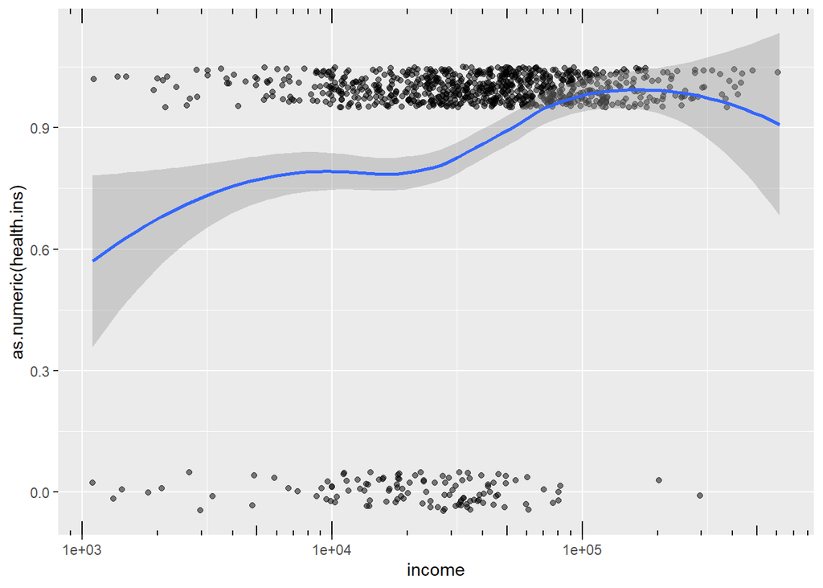

```r
ggplot(subset(custdata, custdata$income > 1000), aes(x=income, y=as.numeric(health.ins))) +
   geom_point(alpha=0.5, position=position_jitter(w=0.05, h=0.05)) + geom_smooth() + scale_x_log10() +
   annotation_logticks(sides="bt")
```

You see that you can replace the income variable with a Boolean variable that indicates whether income is less than $20,000

```r
custdata$income.lt.20K <- custdata$income < 20000
summary(custdata$income.lt.20K)
```

```
##    Mode   FALSE    TRUE
## logical     678     322
```

```r
brks <- c(0, 25, 65, Inf)
custdata$age.range <- cut(custdata$age,
breaks=brks, include.lowest=T)
summary(custdata$age.range)
```

```
##   [0,25]  (25,65] (65,Inf]
##       56      732      212
```

# NORMALIZATION AND RESCALING

Normalization is useful when absolute quantities are less meaningful than relative ones. For example, you might be less interested in a customer’s absolute age than you are in how old or young they are relative to a “typical” customer. Let’s take the mean age of your customers to be the typical age. You can normalize by that, as shown in the following listing

```r
summary(custdata$age)
```

```
##    Min. 1st Qu.  Median    Mean 3rd Qu.    Max.
##     0.0    38.0    50.0    51.7    64.0   146.7
```

```r
meanage <- mean(custdata$age)
custdata$age.normalized <- custdata$age/meanage
summary(custdata$age.normalized)
```

```
##    Min. 1st Qu.  Median    Mean 3rd Qu.    Max.
##  0.0000  0.7350  0.9671  1.0000  1.2379  2.8372
```

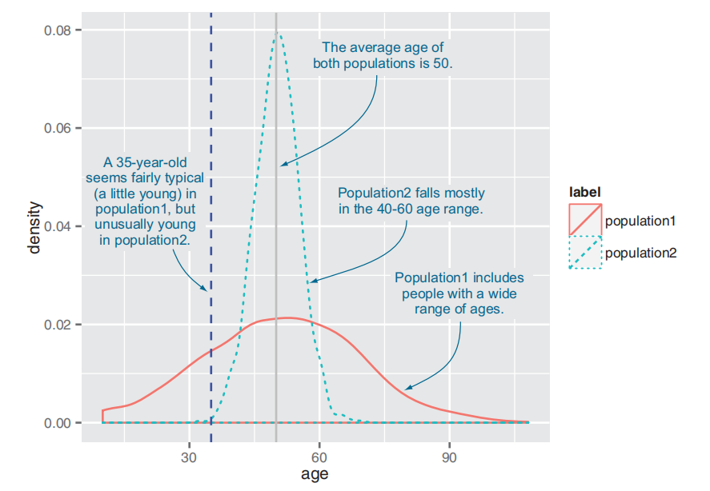

Summarizing age You can rescale your data by using the standard deviation as a unit of distance.

```r
summary(custdata$age)
```

```
##    Min. 1st Qu.  Median    Mean 3rd Qu.    Max.
##     0.0    38.0    50.0    51.7    64.0   146.7
```

```r
meanage <- mean(custdata$age)
stdage <- sd(custdata$age)
meanage
```

```
## [1] 51.69981
```

```r
stdage
```

```
## [1] 18.86343
```

```r
custdata$age.normalized <- (custdata$age-meanage)/stdage
summary(custdata$age.normalized)
```

```
##     Min.  1st Qu.   Median     Mean  3rd Qu.     Max.
## -2.74074 -0.72626 -0.09011  0.00000  0.65207  5.03516
```

Now, values less than -1 signify customers younger than typical; values greater than 1 signify customers older than typical. #LOG TRANSFORMATION

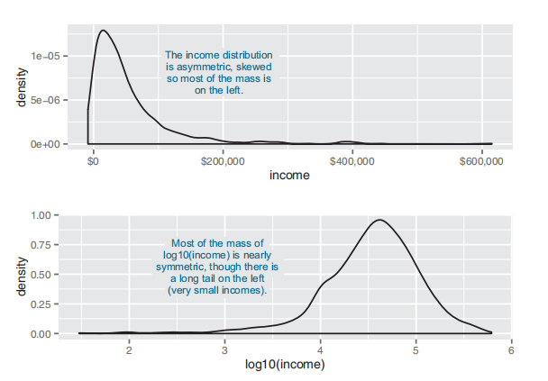

In regression, for example, the choice of logarithm affects the magnitude of the coefficient that corresponds to the logged variable, but it does not affect the value of the outcome.

We like to use log base 10 for monetary amounts, because orders of ten seem natural for money: $100, $1000, $10,000, and so on. The transformed data is easy to read Taking the logarithm only works if the data is non-negative.

There are other transforms, such as arcsinh, that you can use to decrease data range if you have zero or negative values.

We don’t always use arcsinh, because we don’t find the values of the transformed data to be meaningful.